### Prediction of Performed Exercise

##### Hanneke - 22-08-2015

**preface**

This analysis makes use of measurements from devices as Jawbone Up, Nike FuelBand and Fitbit. We will predict the class of exercise people were performing.

Therefore we make use of measurements of six young participants who were asked to perform one set of 10 repetitions of the Unilateral Dumbbell Biceps Curl in five different fashions:

- Class A: exactly according to the specification
- Class B: throwing the elbows to the front
- Class C: lifting the dumbbell only halfway
- Class D: lowering the dumbbell only halfway
- Class E: throwing the hips to the front

**Preparation: used libraries**

```r
library(caret)
```

**Preparation: loading and cleaning data**

The data for this project come was obteined from http://groupware.les.inf.puc-rio.br/har. Two data sets were available, a training set and a test set for which 20 individuals without any classification for the class of exercise was available.

All variables with at least one “NA” are excluded from the analysis. Variables related to time and user information are excluded. Same variables are maintained in the test data set.

```r
#Data loading
setwd("/Users/hanneke/Documents/knowledge/training_data_scientist/machine_learning")
pml_train<-read.csv("pml-training.csv", header=T, na.strings=c("NA", "#DIV/0!"))
pml_test<-read.csv("pml-testing.csv", header=T, na.string=c("NA", "#DIV/0!"))

## NA exclusion for all available variables
pml_train<-pml_train[, apply(pml_train, 2, function(x) !any(is.na(x)))]
dim(pml_train)
```

```
## [1] 19622    60
```

```r
## delete variables with user information and time
pml_train<-pml_train[,-c(1:8)]
dim(pml_train)
```

```
## [1] 19622    52
```

```r
## 20 test cases provided clean info - Validation data set
pml_test<-pml_test[,names(pml_train[,-52])]
dim(pml_test)
```

```
## [1] 20 51
```

```r
# one column less, the output
```

**Data cleaning**

Partitioning is performed to obtain a 75% training set and a 25% test set from the training set

```r
# make train and test set
inTrain<-createDataPartition(y=pml_train$classe, p=0.75,list=F)
training_set<-pml_train[inTrain,]
test_set<-pml_train[-inTrain,]
#Training and test set dimensions
dim(training_set)
```

```
## [1] 14718    52
```

```r
dim(test_set)
```

```
## [1] 4904   52
```

**Data exploration**

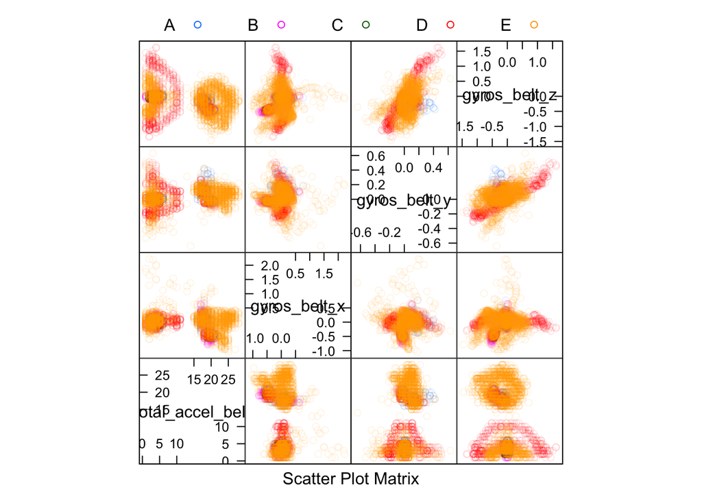

```r
# Make a feature plot of some variables
featurePlot(x = training_set[, 3:6],y=training_set$classe,plot="pairs",alpha=.1, auto.key = list(columns = 5))
```

**Model and model results**

```r
# Build the model
set.seed(13333)
fit_control<-trainControl(method="cv", number=5, allowParallel=T, verbose=T)
rffit<-train(classe~.,data=training_set, method="rf", trControl=fit_control, verbose=F)
#test it on the training set
predrf_train<-predict(rffit, newdata=training_set)
confusionMatrix(predrf_train, training_set$classe)
```

```
## Confusion Matrix and Statistics
##
##           Reference
## Prediction    A    B    C    D    E
##          A 4185    0    0    0    0
##          B    0 2848    0    0    0
##          C    0    0 2567    0    0
##          D    0    0    0 2412    0
##          E    0    0    0    0 2706
##
## Overall Statistics
##
##                Accuracy : 1
##                  95% CI : (0.9997, 1)
##     No Information Rate : 0.2843
##     P-Value [Acc > NIR] : < 2.2e-16
##
##                   Kappa : 1
##  Mcnemar's Test P-Value : NA
##
## Statistics by Class:
##
##                      Class: A Class: B Class: C Class: D Class: E
## Sensitivity            1.0000   1.0000   1.0000   1.0000   1.0000
## Specificity            1.0000   1.0000   1.0000   1.0000   1.0000
## Pos Pred Value         1.0000   1.0000   1.0000   1.0000   1.0000
## Neg Pred Value         1.0000   1.0000   1.0000   1.0000   1.0000
## Prevalence             0.2843   0.1935   0.1744   0.1639   0.1839
## Detection Rate         0.2843   0.1935   0.1744   0.1639   0.1839
## Detection Prevalence   0.2843   0.1935   0.1744   0.1639   0.1839
## Balanced Accuracy      1.0000   1.0000   1.0000   1.0000   1.0000
```

```r
# test it on generated test set
predrf_test<-predict(rffit, newdata=test_set)
confusionMatrix(predrf_test, test_set$classe)
```

```
## Confusion Matrix and Statistics
##
##           Reference
## Prediction    A    B    C    D    E
##          A 1394    3    0    0    0
##          B    1  941    5    0    0
##          C    0    5  846    6    0
##          D    0    0    4  796    0
##          E    0    0    0    2  901
##
## Overall Statistics
##
##                Accuracy : 0.9947
##                  95% CI : (0.9922, 0.9965)
##     No Information Rate : 0.2845
##     P-Value [Acc > NIR] : < 2.2e-16
##
##                   Kappa : 0.9933
##  Mcnemar's Test P-Value : NA
##
## Statistics by Class:
##
##                      Class: A Class: B Class: C Class: D Class: E
## Sensitivity            0.9993   0.9916   0.9895   0.9900   1.0000
## Specificity            0.9991   0.9985   0.9973   0.9990   0.9995
## Pos Pred Value         0.9979   0.9937   0.9872   0.9950   0.9978
## Neg Pred Value         0.9997   0.9980   0.9978   0.9981   1.0000
## Prevalence             0.2845   0.1935   0.1743   0.1639   0.1837
## Detection Rate         0.2843   0.1919   0.1725   0.1623   0.1837
## Detection Prevalence   0.2849   0.1931   0.1748   0.1631   0.1841
## Balanced Accuracy      0.9992   0.9950   0.9934   0.9945   0.9998
```

**Predict 20 test-cases**

```r
pred20<-predict(rffit, newdata=pml_test)
# Output for the prediction of the 20 cases provided
pred20
```

```
##  [1] B A B A A E D B A A B C B A E E A B B B
## Levels: A B C D E
```

The function below is used to obtain single text files to test the outcome. 20 out of 20 hits also confirmed the accuracy of the obtained models.

```r
pml_write_files = function(x){
  n = length(x)
  for(i in 1:n){
    filename = paste0("problem_id_",i,".txt")
    write.table(x[i],file=filename,quote=FALSE,row.names=FALSE,col.names=FALSE)
  }
}

pml_write_files(pred20)
```

**Conclusion**

The random forest model can do a good estimation with exercise is done with the measurements of the bracelets.